# 実習1: ランダム化比較試験

Jaehyun Song

Last Update: 2020-09-03

# パッケージとデータの読み込み

ここでは以下の3つのパッケージを使います。

- `tidyverse`: R界の神様、Hadley先生のパッケージ集。主に`dplyr`と`ggplot2`を使います。
- `coefplot`: 回帰分析の結果を見やすく可視化してくれるパッケージです。
- `BalanceR`: バランスチェックのパッケージです。GitHub経由でインストールする必要があり、後ほど解説します。

他にもいくつかのパッケージを使用しますが、必須ではありません。

- `summarytools`: 記述統計を見やすく見せてくれます。なくてもOK
- `DT`: データフレーム（または、tibble）形式のデータを見やすく出力するパッケージです。R Markdownを使用しない場合は使わなくて結構です。
- `broom`: 推定結果をデータフレーム形式に要約する`tidy()`関数が含まれています。
- `purrr`: データフレームにおける行単位反復演算パッケージです。
- `stargazer`: 回帰分析の推定値を表でまとめるパッケージです。

つづいて、`Day1_Data3.csv`を`GG.df`と名付けて格納します。

```r
library(tidyverse)    # Thanks, Hadley!
library(summarytools) # データの記述統計
library(coefplot)     # 係数の可視化
library(DT)           # データフレームを見やすく
```

```r
# dfはdata.frameの略です。データのパスは各自変更すること
GG.df <- read_csv("Day1_Data3.csv")
```

データの詳細については[Gerber, Green, and Larimer (2008)](https://www.cambridge.org/core/journals/american-political-science-review/article/social-pressure-and-voter-turnout-evidence-from-a-largescale-field-experiment/11E84AF4C0B7FBD1D20C855972C2C3EB)を参照してください。まずはデータの大きさを確認します。

```r
dim(GG.df)
```

```
## [1] 344084     16
```

```r
print(GG.df, n = 20)
```

```
## # A tibble: 344,084 x 16
##    sex     yob g2000 g2002 g2004 p2000 p2002 p2004 treatment cluster voted hh_id
##    <chr> <dbl> <chr> <chr> <chr> <chr> <chr> <chr> <chr>       <dbl> <chr> <dbl>
##  1 male   1941 yes   yes   yes   no    yes   No    Civic Du…       1 No        1
##  2 fema…  1947 yes   yes   yes   no    yes   No    Civic Du…       1 No        1
##  3 male   1951 yes   yes   yes   no    yes   No    Hawthorne       1 Yes       2
##  4 fema…  1950 yes   yes   yes   no    yes   No    Hawthorne       1 Yes       2
##  5 fema…  1982 yes   yes   yes   no    yes   No    Hawthorne       1 Yes       2
##  6 male   1981 no    no    yes   no    no    No    Control         1 No        3
##  7 fema…  1959 yes   yes   yes   no    yes   No    Control         1 Yes       3
##  8 male   1956 yes   yes   yes   no    yes   No    Control         1 Yes       3
##  9 fema…  1968 no    no    yes   no    yes   No    Control         1 No        4
## 10 male   1967 yes   yes   yes   no    yes   No    Control         1 No        4
## 11 male   1941 yes   yes   yes   no    no    Yes   Control         1 Yes       5
## 12 male   1945 yes   yes   yes   no    no    No    Hawthorne       1 No        6
## 13 fema…  1949 yes   yes   yes   no    yes   No    Hawthorne       1 Yes       6
## 14 fema…  1969 yes   no    yes   no    no    Yes   Control         1 No        7
## 15 fema…  1967 yes   yes   yes   yes   yes   Yes   Control         1 Yes       8
## 16 male   1961 yes   yes   yes   no    yes   Yes   Control         1 Yes       8
## 17 fema…  1957 yes   yes   yes   no    no    No    Self            1 No        9
## 18 male   1955 no    no    yes   no    no    No    Self            1 No        9
## 19 fema…  1943 yes   yes   yes   no    yes   No    Control         1 Yes      10
## 20 male   1939 yes   yes   yes   no    yes   No    Neighbors       1 Yes      11
## # … with 344,064 more rows, and 4 more variables: hh_size <dbl>,
## #   numberofnames <dbl>, p2004_mean <dbl>, g2004_mean <dbl>
```

R Markdownを使用している場合、`DT::datatable()`関数を使用すると、より見やすい表として出力されます。ちなみに、`DT::datatable()`とは`DT`パッケージの`datatable()`関数を意味します。普段は`DT::`を略しても構いませんが、もし、複数のパッケージが同じ名前の関数を提供している場合は、このようにパッケージ名を明記します。今後、「`XX`パッケージの`YY`関数」を`XX:YY`と表記します。

```r
# GG.dfの1行から100行までを、datatable形式で出力
datatable(GG.df[1:100, ])
```

|  | sex | yob | g2000 | g2002 | g2004 | p2000 | p2002 | p2004 | treatment | cluster | voted | hh_id | hh_size | numberofnames | p2004_mean | g2004_mean |
| --- | --- | --- | --- | --- | --- | --- | --- | --- | --- | --- | --- | --- | --- | --- | --- | --- |
| 1 | male | 1941 | yes | yes | yes | no | yes | No | Civic Duty | 1 | No | 1 | 2 | 21 | 0.0952381 | 0.8571429 |
| 2 | female | 1947 | yes | yes | yes | no | yes | No | Civic Duty | 1 | No | 1 | 2 | 21 | 0.0952381 | 0.8571429 |
| 3 | male | 1951 | yes | yes | yes | no | yes | No | Hawthorne | 1 | Yes | 2 | 3 | 21 | 0.047619 | 0.8571429 |
| 4 | female | 1950 | yes | yes | yes | no | yes | No | Hawthorne | 1 | Yes | 2 | 3 | 21 | 0.047619 | 0.8571429 |
| 5 | female | 1982 | yes | yes | yes | no | yes | No | Hawthorne | 1 | Yes | 2 | 3 | 21 | 0.047619 | 0.8571429 |
| 6 | male | 1981 | no | no | yes | no | no | No | Control | 1 | No | 3 | 3 | 21 | 0.047619 | 0.9047619 |
| 7 | female | 1959 | yes | yes | yes | no | yes | No | Control | 1 | Yes | 3 | 3 | 21 | 0.047619 | 0.9047619 |
| 8 | male | 1956 | yes | yes | yes | no | yes | No | Control | 1 | Yes | 3 | 3 | 21 | 0.047619 | 0.9047619 |
| 9 | female | 1968 | no | no | yes | no | yes | No | Control | 1 | No | 4 | 2 | 21 | 0.047619 | 0.9047619 |
| 10 | male | 1967 | yes | yes | yes | no | yes | No | Control | 1 | No | 4 | 2 | 21 | 0.047619 | 0.9047619 |

[output cut: 90 more lines]

実は変数が約10個を超えてしまうと、大画面のモニターじゃない限り、かなり見づらいです。ここでは、「分析のためのデータとはどのような構造をしているのか」を確認するだけで十分です。

# 記述統計を見る

データフレーム全体の記述統計 (平均値、頻度など)を見る簡単な方法は`summary(データフレーム名)`です。

```r
summary(GG.df)
```

```
##      sex                 yob          g2000              g2002
##  Length:344084      Min.   :1900   Length:344084      Length:344084
##  Class :character   1st Qu.:1947   Class :character   Class :character
##  Mode  :character   Median :1956   Mode  :character   Mode  :character
##                     Mean   :1956
##                     3rd Qu.:1965
##                     Max.   :1986
##     g2004              p2000              p2002              p2004
##  Length:344084      Length:344084      Length:344084      Length:344084
##  Class :character   Class :character   Class :character   Class :character
##  Mode  :character   Mode  :character   Mode  :character   Mode  :character
##
##
##
##   treatment            cluster         voted               hh_id
##  Length:344084      Min.   :    1   Length:344084      Min.   :     1
##  Class :character   1st Qu.: 2475   Class :character   1st Qu.: 44545
##  Mode  :character   Median : 4986   Mode  :character   Median : 89742
##                     Mean   : 4989                      Mean   : 89795
##                     3rd Qu.: 7510                      3rd Qu.:135172
##                     Max.   :10000                      Max.   :180000
##     hh_size      numberofnames     p2004_mean       g2004_mean
##  Min.   :1.000   Min.   : 1.00   Min.   :0.0000   Min.   :0.3810
##  1st Qu.:2.000   1st Qu.:21.00   1st Qu.:0.1905   1st Qu.:0.9048
##  Median :2.000   Median :21.00   Median :0.2857   Median :0.9524
##  Mean   :2.184   Mean   :20.93   Mean   :0.3057   Mean   :0.9239
##  3rd Qu.:2.000   3rd Qu.:21.00   3rd Qu.:0.4286   3rd Qu.:1.0000
##  Max.   :8.000   Max.   :21.00   Max.   :1.0000   Max.   :1.0000
```

記述統計をもっと見やすく見せてくれる関数として`summarytools`内にある`dfSummary()`があります。R Markdownに埋め込む場合以下のようなコマンドを打ち込みますが、普段の状況では`view(dfSummary(GG.df))`と打ち込みます (もっと見やすい)。

```r
print(dfSummary(GG.df, style = "grid",
                plain.ascii = FALSE, graph.magnif = 0.85),
      method = "render", headings = FALSE)
```

| **No** | **Variable** | **Stats / Values** | **Freqs (% of Valid)** | **Graph** | **Valid** | **Missing** |
| --- | --- | --- | --- | --- | --- | --- |
| 1 | sex [character] | 1. female 2. male | 171795 ( 49.9% ) 172289 ( 50.1% ) |  | 344084 (100%) | 0 (0%) |
| 2 | yob [numeric] | Mean (sd) : 1956.2 (14.4) min < med < max: 1900 < 1956 < 1986 IQR (CV) : 18 (0) | 86 distinct values |  | 344084 (100%) | 0 (0%) |
| 3 | g2000 [character] | 1. no 2. yes | 54095 ( 15.7% ) 289989 ( 84.3% ) |  | 344084 (100%) | 0 (0%) |
| 4 | g2002 [character] | 1. no 2. yes | 64942 ( 18.9% ) 279142 ( 81.1% ) |  | 344084 (100%) | 0 (0%) |
| 5 | g2004 [character] | 1. yes | 344084 ( 100.0% ) |  | 344084 (100%) | 0 (0%) |
| 6 | p2000 [character] | 1. no 2. yes | 257464 ( 74.8% ) 86620 ( 25.2% ) |  | 344084 (100%) | 0 (0%) |
| 7 | p2002 [character] | 1. no 2. yes | 209947 ( 61.0% ) 134137 ( 39.0% ) |  | 344084 (100%) | 0 (0%) |
| 8 | p2004 [character] | 1. No 2. Yes | 205934 ( 59.9% ) 138150 ( 40.2% ) |  | 344084 (100%) | 0 (0%) |
| 9 | treatment [character] | 1. Civic Duty 2. Control 3. Hawthorne 4. Neighbors 5. Self | 38218 ( 11.1% ) 191243 ( 55.6% ) 38204 ( 11.1% ) 38201 ( 11.1% ) 38218 ( 11.1% ) |  | 344084 (100%) | 0 (0%) |
| 10 | cluster [numeric] | Mean (sd) : 4989.1 (2885.9) min < med < max: 1 < 4986 < 10000 IQR (CV) : 5035 (0.6) | 10000 distinct values |  | 344084 (100%) | 0 (0%) |
| 11 | voted [character] | 1. No 2. Yes | 235388 ( 68.4% ) 108696 ( 31.6% ) |  | 344084 (100%) | 0 (0%) |
| 12 | hh_id [numeric] | Mean (sd) : 89795.2 (51945.3) min < med < max: 1 < 89742 < 180000 IQR (CV) : 90627.5 (0.6) | 180002 distinct values |  | 344084 (100%) | 0 (0%) |
| 13 | hh_size [numeric] | Mean (sd) : 2.2 (0.8) min < med < max: 1 < 2 < 8 IQR (CV) : 0 (0.4) | 1 : 47834 ( 13.9% ) 2 : 214086 ( 62.2% ) 3 : 57474 ( 16.7% ) 4 : 20916 ( 6.1% ) 5 : 3315 ( 1.0% ) 6 : 402 ( 0.1% ) 7 : 49 ( 0.0% ) 8 : 8 ( 0.0% ) |  | 344084 (100%) | 0 (0%) |
| 14 | numberofnames [numeric] | Mean (sd) : 20.9 (0.5) min < med < max: 1 < 21 < 21 IQR (CV) : 0 (0) | 20 distinct values |  | 344084 (100%) | 0 (0%) |
| 15 | p2004_mean [numeric] | Mean (sd) : 0.3 (0.2) min < med < max: 0 < 0.3 < 1 IQR (CV) : 0.2 (0.6) | 121 distinct values |  | 344084 (100%) | 0 (0%) |
| 16 | g2004_mean [numeric] | Mean (sd) : 0.9 (0.1) min < med < max: 0.4 < 1 < 1 IQR (CV) : 0.1 (0.1) | 52 distinct values |  | 344084 (100%) | 0 (0%) |

Generated by summarytools 0.9.6 ([R](https://www.r-project.org/) version 4.0.2)  
2020-09-03

# データのクリーニング

## 変数のダミー化

まずは、性別と投票有無をダミー変数にします。たとえば、性別を表す`sex`変数は`"male"`と`"female"`といった2つの値で構成されます。パソコンにとっては文字列よりは数字の方が都合が良いので、これらの値を数値化します。

具体的には、`Female`という変数を作成し、もし`sex`が`"female"`なら`1`を、それ以外なら`0`を入れます。変数の作成には`dplyr`パッケージの`mutate()`関数を、条件による値の割り当てには`dplyr`パッケージの`if_else()`関数を使います[^1]。`if_else()`関数は`if_else(条件, 条件が満たされる場合, それ以外の場合)`です。

`mutate()`と`if_else()`関数の使い方は以下の通りです。

```r
データフレーム名1 <- データフレーム名2 %>%
  mutate(新しい変数名 = if_else(条件式, 条件がTRUEの場合, 条件がFALSEの場合))
```

ここで登場する`%>%`はパイプ（pipe）演算子と呼ばれるもので、「今どきのR」では欠かせない演算子となります。これはパイプの前にあるオブジェクトをパイプ後にある関数の第一引数として渡すことを意味します。詳細は[宋・矢内資料](https://www.jaysong.net/RBook/datahandling1.html#handling1-pipe)を参照してください。

`データフレーム名1`と`データフレーム名2`が同じなら、上書きとなります。別の名前なら`データフレーム名1`という新しいデータオブジェクトが生成されます。`mutate()`は新しい列を作成する関数です。たとえば`muate()`の中身が`Female = if_else(sex == "female", 1, 0)`なら、`Female`という新しい列を作成し、その列の中身は`if_else()`の処理結果となります。

`if_else()`の条件式は`sex`の値が`"female"`か否かを判定します。そして判定結果がTRUE（真）なら1を、FALSE（偽）0を返します。条件式において「同値」は`=`でなく、`==`であることに注意してください。また、`"female"`は`"`で囲みますが、`0`と`1`は囲みません。文字型、factor型オブジェクトの値は`"`で囲みますが、数値型は`"`を使いません。`"0"`にすると、数値型でなく文字型として値を返します。

2000年、2002年、2004年、2006年に投票したか否かを表す変数も同様に処理します。

```r
# dplyrを使う場合
GG.df <- GG.df %>%
    mutate(Female = if_else(sex   == "female", 1, 0),
           V2000  = if_else(p2000 == "yes",    1, 0),
           V2002  = if_else(p2002 == "yes",    1, 0),
           V2004  = if_else(p2004 == "Yes",    1, 0),
           Voted  = if_else(voted == "Yes",    1, 0))
```

```r
# dplyrを使わない場合
GG.df$Female <- ifelse(GG.df$sex == "female", 1, 0)

GG.df$V2000  <- ifelse(GG.df$p2000 == "yes",  1, 0)
GG.df$V2002  <- ifelse(GG.df$p2002 == "yes",  1, 0)
GG.df$V2004  <- ifelse(GG.df$p2004 == "yes",  1, 0)
GG.df$Voted  <- ifelse(GG.df$voted == "yes",  1, 0)
```

## 処置変数のfactor化

ここはしてもしなくても問題ありませんが、プロットなどで順番を自分で決めたい場合は、文字型をfacotr型に変換した方が便利です。factor型の詳細は[宋・矢内資料](https://www.jaysong.net/RBook/factor.html)を参照してください。ちなみに文字型のままだと、順番はアルファベット順になります。やはり統制群を一番最初か最後に置きたいので、今回は`levels = c(...)`を指定して、要素に順番を付けましょう。

新しい処置変数として`Treat`という変数を作成します。これは既存の`treatment`変数を`factor()`関数を使ってfactor型に変換した変数です。そして、値の順番を`levels = ...`引数で指定します。`GG.df`の`treatment`変数がどのような値で構成されているかを確認するためには`unique()`関数を使います。

```r
# ベクトルを構成する要素を出力
unique(GG.df$treatment)
```

```
## [1] "Civic Duty" "Hawthorne"  "Control"    "Self"       "Neighbors"
```

`treatment`列は`"Civic Duty"`、`"Control"`、`"Hawthorne"`、`"Neighbors"`、`"Self"`の値のみで構成されています。そして、これらの値の順番を付けたいとします。その順番を`levels =`引数の実引数[^2]として指定します。今回は統制群、Civic Duty群、Hawthorne群、Self群、Neighbors群の順番にしましょう。

```r
# dplyrを使う場合
GG.df <- GG.df %>%
    mutate(Treat = factor(treatment,
                          levels = c("Control", "Civic Duty",
                                     "Hawthorne", "Self", "Neighbors")))
```

`GG.df`に新しく生成された`Treat`列のデータ型を`class()`型で確認します。

```r
class(GG.df$Treat)
```

```
## [1] "factor"
```

factor型になっていますね。また、ちゃんと順番付になっているかを`levels()`関数を使って確認します。

```r
levels(GG.df$Treat)
```

```
## [1] "Control"    "Civic Duty" "Hawthorne"  "Self"       "Neighbors"
```

先ほど指定した順番でfactorの水準が並んでいることが分かります。

# バランスチェック

## 簡単な方法

それでは、無作為割当が成功しているかを確認するためにバランスチェックをしてみましょう。まずは、単純に平均値を比較ししてみましょう。たとえば、誕生年（`yob`）にグループごとの差があるかを確認したいとします。この場合、（１）実験群ごとに（２）`yob`の平均値を計算する必要があります。グループごとに計算を行うにはデータを`group_by()`変数を使ってグループ化します。そして、ある変数の記述統計量を計算するには`summarise()`関数を使います。どれも`dplyr`パッケージの関数です。たとえば、`Treat`の値でグループ化し、`yob`の平均値を計算した結果を`YearOfBirth`という列として出力するとします。`group_by()`にはグループ化の基準となる変数を指定します。`summarise()`関数の中身は`出力される列名 = 関数(引数)`となります。

```r
GG.df %>%
  group_by(Treat) %>%
  summarise(YearOfBirth = mean(yob),
            .groups     = "drop")
```

```
## # A tibble: 5 x 2
##   Treat      YearOfBirth
##   <fct>            <dbl>
## 1 Control          1956.
## 2 Civic Duty       1956.
## 3 Hawthorne        1956.
## 4 Self             1956.
## 5 Neighbors        1956.
```

各グループごとに`yob`変数の平均値が計算され、その結果が`YearOfBirth`列として出力されます。`.groups`引数は無視しても構いませんが、dplyr 1.0.0以降では明示することが推奨されています。`.groups`引数の詳細は[宋・矢内の参考資料](https://www.jaysong.net/RBook/datahandling2.html#handling2-group)を参照してください。

これらの作業を女性（`Female`）、世帯人数（`hh_size`）、誕生年（`yob`）、2000年から2004年からの投票有無（`V2000`、`V2002`、`V2004`）に対して行います。

```r
GG.df %>% # GG.dfを
    group_by(Treat) %>% # Treat変数でグループ化し、
    summarise(Female  = mean(Female), # これらの変数の平均値
              HH_Size = mean(hh_size),# を表示させましょう。
              YOB     = mean(yob),
              V2000   = mean(V2000),
              V2002   = mean(V2002),
              V2004   = mean(V2004),
              .groups = "drop")       # dplyr 1.0.0以降では指定する必要あり
```

```
## # A tibble: 5 x 7
##   Treat      Female HH_Size   YOB V2000 V2002 V2004
##   <fct>       <dbl>   <dbl> <dbl> <dbl> <dbl> <dbl>
## 1 Control     0.499    2.18 1956. 0.252 0.389 0.400
## 2 Civic Duty  0.500    2.19 1956. 0.254 0.389 0.399
## 3 Hawthorne   0.499    2.18 1956. 0.250 0.394 0.403
## 4 Self        0.500    2.18 1956. 0.251 0.392 0.402
## 5 Neighbors   0.500    2.19 1956. 0.251 0.387 0.407
```

グループは5つあり、それぞれ女性率、世帯人数、誕生年、2000・2002・2004年投票の投票有無はほぼ同じです。つまり、バランスは取れていると考えられます。

## パッケージを利用する

標準化バイアス/標準化差分 (Standardized Bias / Standardized Diffenece; 以下、SB)を用いたバランスチェックをやってみましょう。SBは以下のように計算可能であり、あまり難しくありません。

$$\text{SB} = 100 \times \frac{\bar{X}_{\text{Treat}}-\bar{X}_{\text{Control}}}{\sqrt{\frac{1}{2}\cdot(s^2_{\text{Treat}} + s^2_{\text{Control}})}},$$

です[^3]。ここで$\bar{X}$は処置前変数の平均値であり、$s^2$は処置前変数の分散である。これが一定数値未満であればバランスが成立していると判断します。この基準はまた恣意的ではありますが、よく用いられる基準としては*絶対値*基準で3か5 (Caliendo and Kopeing, 2008)[^4]や、10 (Normand et al., 2001[^5]; Austine and Mamdani, 2005[^6])、25[^7]があります。

これらの作業は自分でやってもいいですが、パッケージが用意されているので積極的に使いましょう。[`cobalt`](https://cran.r-project.org/web/packages/cobalt/vignettes/cobalt_A0_basic_use.html)という素晴らしいパッケージもあり、様々な機能が搭載されていますが、ここではもっと簡単に使える[`BalanceR`](https://github.com/JaehyunSong/BalanceR)パッケージを使ってみましょう。[誰が作ったかは分かりませんが](https://www.jaysong.net)、非常に使いやすいパッケージです。

`BalanceR`パッケージはCRANではなく、[GitHub](https://github.com/)経由で配布されていますので、`devtools::install_github()`関数を使います。`devtools`パッケージがない場合は、先に`devtools`からインストールしておきましょう。最近はCRANでなく、GitHub経由でパッケージを公開する開発者も多いので、入れておいては損はありません。

```r
install.packages("devtools")

devtools::install_github("JaehyunSong/BalanceR")
```

それではパッケージを読み込みます。

```r
library(BalanceR)
```

パッケージの使い方は[`BalanceR`](https://github.com/JaehyunSong/BalanceR)パッケージのホームページに譲ります。ここでは簡単な使い方のみ解説します。`BalanceR()`関数は`data`、`group`、`cov`の3つの引数のみを必要とします。`data`はデータフレーム名、`group`は実験群を示す変数名、`cov`はバランスをチェックする共変量の変数名です。共変量の指定は`dplyr`パッケージの`select()`関数と同じやり方で結構です[^8]。

```r
GG.Blc <- GG.df %>%
  BalanceR(group = Treat, cov = c(Female,
                                  Household_Size = hh_size,
                                  Year_of_Brith  = yob,
                                  Voted2000      = V2000,
                                  Voted2002      = V2002,
                                  Voted2004      = V2004))
```

それでは結果を確認してみましょう。

```r
print(GG.Blc)
```

[output not shown]

[output cut: 27 more lines]

かなり長い表が表示されます。実験群が5つもあり、それぞれのペアごとにSBが計算されるため、10個の組み合わせが表示されるからです。

最初の1列は共変量の変数名であり、つづいて各実験群ごとの平均値と標準誤差が表示されます。`SB:`で始まる列からが標準化差分です。たとえば、`SB:Control-Civic Duty`列は`Control`群と`Civic Duty`群間の標準化差分です。しかし、このままだとかなり読みづらいので、可視化しましょう。

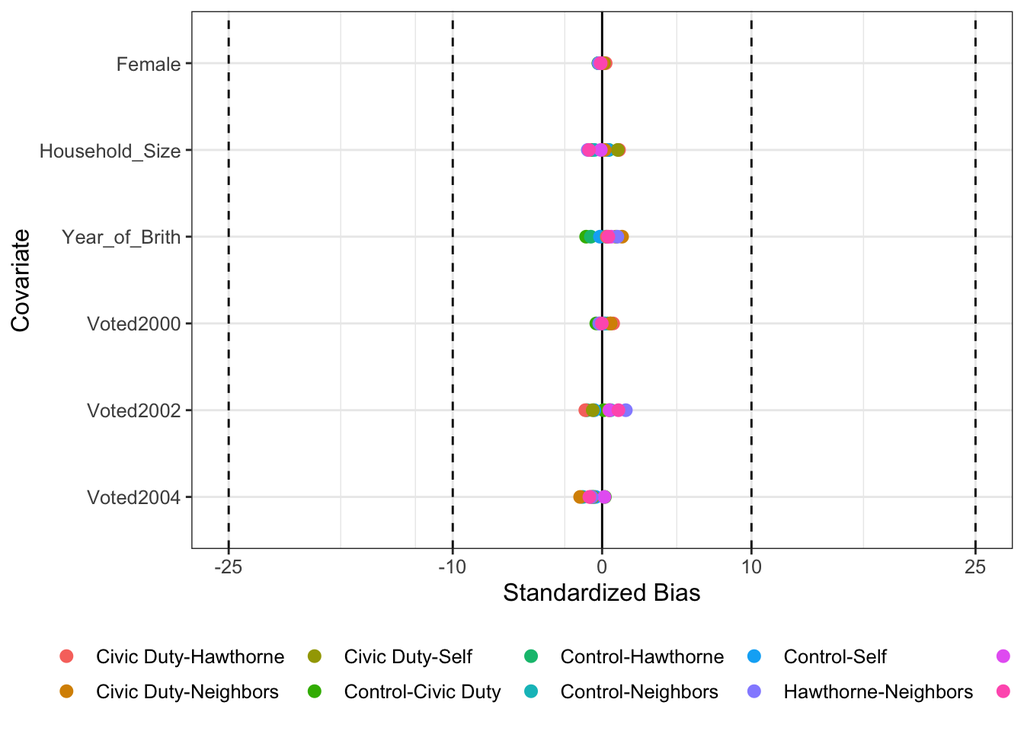

```r
# GG.Blcの可視化 (-25, -10, 10, 25に垂直線を引く)
plot(GG.Blc, vline = c(10, 25))
```

下の凡例が微妙なので、右側に移動させます。

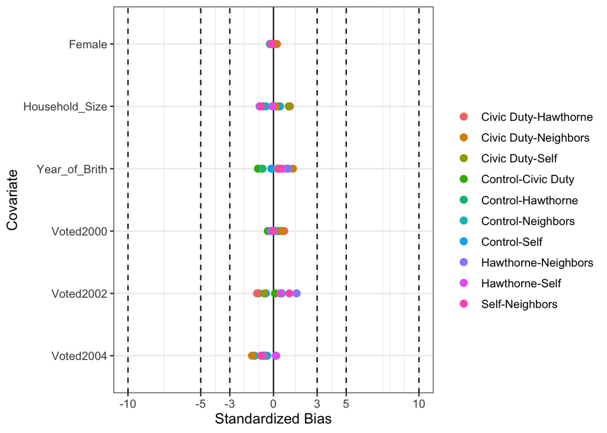

```r
plot(GG.Blc) +
  theme(legend.position = "right")
```

だいぶ見やすくなりましたね。これを見ると、SBが極めて小さく、どのペアでも絶対値が非常に小さいのが分かります。これだとバランスが取れていると判断できるでしょう。

# 処置効果の推定

## まずは、グラフから

まず、`Treat`変数 (処置変数)ごとに`Voted`変数 (結果変数)の平均値がいくらかを計算してみましょう。

```r
GG.df2 <- GG.df %>%                  # GG.dfを使って
    group_by(Treat) %>%              # Treatでグループ化し、
    summarise(Voted   = mean(Voted), # Voted変数の平均値を計算
              .groups = "drop")      # グループ化の解除 (dplyr 1.0.0以降)

GG.df2
```

```
## # A tibble: 5 x 2
##   Treat      Voted
##   <fct>      <dbl>
## 1 Control    0.297
## 2 Civic Duty 0.315
## 3 Hawthorne  0.322
## 4 Self       0.345
## 5 Neighbors  0.378
```

これを見ると、統制群の投票参加率が最も低く、`Neighbors`処置を受けた人の参加率が最も高いことが分かります。表でも問題ありませんが、これも可視化してみましょう。

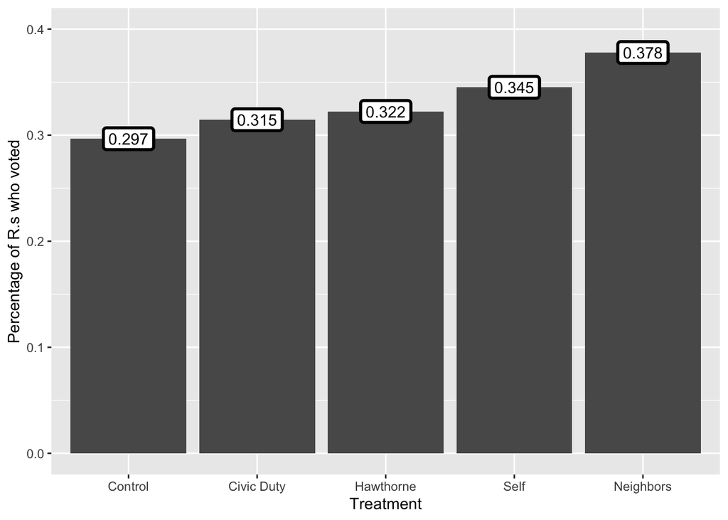

```r
GG.df2 %>%
    ggplot() +
    # x軸はTreat, y軸はVotedの平均値
    geom_bar(aes(x = Treat, y = Voted), stat = "identity") +
    # 棒に数値も付ける
    geom_label(aes(x = Treat, y = Voted,
                label = round(Voted, 3)), label.size = 1) +
    # 軸ラベル
    labs(x = "Treatment", y = "Percentage of R.s who voted") +
    # y軸の最小値は0, 最大値は0.4にする
    coord_cartesian(ylim = c(0, 0.4))
```

もう一つのやり方として“処置群に比べてどれほど高いか/低いか”を示す棒グラフが考えられます。これは単純に全ての値から統制群の平均値を引くだけでOKです。処置群の平均値から統制群の平均値を引いたものが**平均処置効果**です。

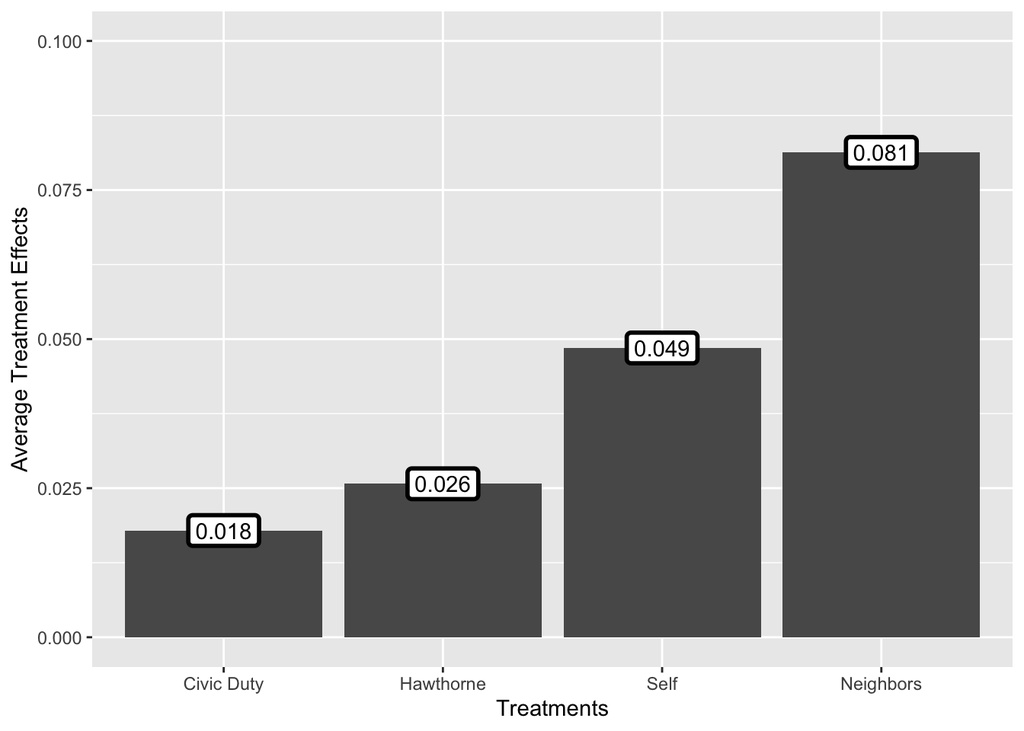

```r
# まずは、処置群の平均値を計算し、CtrlMeanに家訓王
CtrlMean <- mean(GG.df$Voted[GG.df$Treat == "Control"])

GG.df3 <- GG.df2 %>%
    # GG.df2から処置群は除外します。どうせ0なんで
    filter(Treat != "Control") %>%
    # Voted列の数値からCtrlMeanを引いた値をATEという新しい列に保存
    mutate(ATE = Voted - CtrlMean)

GG.df3 %>%
    ggplot() +
    geom_bar(aes(x = Treat, y = ATE), stat = "identity") +
    geom_label(aes(x = Treat, y = ATE,
                   label = round(ATE, 3)), label.size = 1) +
    labs(x = "Treatments", y = "Average Treatment Effects") +
    coord_cartesian(ylim = c(0, 0.1))
```

また、よく見るのが、棒グラフにエラーバーを付けたものです。エラーバーの区間は信頼区間を意味します。ある変数の信頼区間を算出する手っ取り早い方法は一変数の*t*検定です。*t*検定は二群間比較以外の場合、つまり一群の平均値が0か否かを検定する場合にも使えます。この場合、ある変数の平均値が0であるという帰無仮説を検定することになります。同時にその変数の95%信頼区間も計算してくれるので便利です。信頼区間は`t検定オブジェクト名$conf.int`で95%信頼区間の下限（`[1]`）と上限（`[2]`）を抽出できます。

まず、`GG.df2`に信頼区間を格納する列を追加し、*t*検定行います。続いて、*t*検定結果のオブジェクトから95%信頼区間のみを抽出します。

```r
# まず信頼区間の最小値と最大値を格納する列を追加する。
GG.df2$conf.low  <- rep(NA, 5) # 長さ5の空ベクトル
GG.df2$conf.high <- rep(NA, 5) # 長さ5の空ベクトル

# 1. GG.dfのtreatmentが" Control"であるケースに絞ってVotedのt検定
Ctrl.t   <- t.test(GG.df$Voted[GG.df$treatment == "Control"])
# 2. GG.dfのtreatmentが" Civic Duty"であるケースに絞ってVotedのt検定
CvcDty.t <- t.test(GG.df$Voted[GG.df$treatment == "Civic Duty"])
# 3. GG.dfのtreatmentが" Hawthorne"であるケースに絞ってVotedのt検定
Hwtrn.t  <- t.test(GG.df$Voted[GG.df$treatment == "Hawthorne"])
# 4. GG.dfのtreatmentが" Neighbors"であるケースに絞ってVotedのt検定
Nghbr.t  <- t.test(GG.df$Voted[GG.df$treatment == "Neighbors"])
# 5. GG.dfのtreatmentが" Self"であるケースに絞ってVotedのt検定
Slf.t    <- t.test(GG.df$Voted[GG.df$treatment == "Self"])

# GG.df2のconf.low列に、各t検定オブジェクトの95%信頼区間の下限を格納
GG.df2$conf.low  <- c(Ctrl.t$conf.int[1],  CvcDty.t$conf.int[1],
                      Hwtrn.t$conf.int[1], Nghbr.t$conf.int[1],
                      Slf.t$conf.int[1])
# GG.df2のconf.high列に、各t検定オブジェクトの95%信頼区間の上限を格納
GG.df2$conf.high <- c(Ctrl.t$conf.int[2],  CvcDty.t$conf.int[2],
                      Hwtrn.t$conf.int[2], Nghbr.t$conf.int[2],
                      Slf.t$conf.int[2])

GG.df2
```

[output not shown]

```r
GG.ttest <- function(Treat){
  command <- paste0("t.test(GG.df$Voted[GG.df$treatment == '", Treat, "'])")
  return(broom::tidy(eval(parse(text = command))))
}

GG.df2 <- GG.df2 %>%
  mutate(ttest = purrr::map(Treat, GG.ttest)) %>%
  unnest(ttest)

GG.df2
```

```
## # A tibble: 5 x 10
##   Treat Voted estimate statistic p.value parameter conf.low conf.high method
##   <fct> <dbl>    <dbl>     <dbl>   <dbl>     <dbl>    <dbl>     <dbl> <chr>
## 1 Cont… 0.297    0.297      284.       0    191242    0.295     0.299 One S…
## 2 Civi… 0.315    0.315      132.       0     38217    0.310     0.319 One S…
## 3 Hawt… 0.322    0.322      135.       0     38203    0.318     0.327 One S…
## 4 Self  0.345    0.345      142.       0     38217    0.340     0.350 One S…
## 5 Neig… 0.378    0.378      152.       0     38200    0.373     0.383 One S…
## # … with 1 more variable: alternative <chr>
```

13行のコードを7行に減らすことができました。しかも、後者の方がもっといろんな情報を含んでいます。`purrr`パッケージに慣れるとコードを数分〜数十分の一まで減らすことができます。時間があればぜひ身につけておきたいスキルです。

とにかく、次のコードを走らせるにはどっちも問題ありません。それでは`GG.df2`の棒グラフにエラーバーを付けてみましょう。先程の棒グラフに`geom_errorbar()`を加えるだけです。横軸はそのまま`Treat`でいいですが、縦軸は最小値 (`ymin`)と最大値 (`ymax`)を指定する必要があります。また、`width = ...`で横の長さも調整してみましょう。

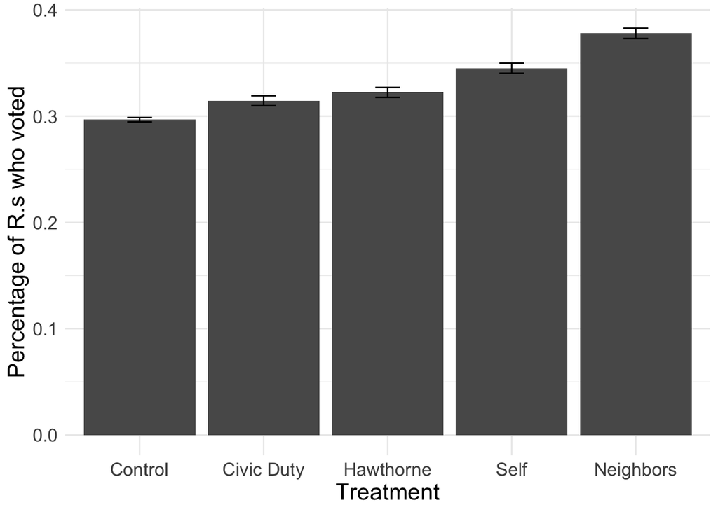

```r
GG.df2 %>%
    ggplot() +
    # x軸はTreat, y軸はVotedの平均値
    geom_bar(aes(x = Treat, y = Voted), stat = "identity") +
    # エラーバーを付ける
    geom_errorbar(aes(x = Treat, ymin = conf.low, ymax = conf.high),
                  width = 0.2) +
    # 軸ラベル
    labs(x = "Treatment", y = "Percentage of R.s who voted") +
    # シンプルなテーマに変えてみました
    theme_minimal() +
    # 文字の大きさも調整してみましょう。
    theme(text = element_text(size = 16))
```

サーベイ実験なら、サンプルサイズが大きくて数千程度なので、ここまで信頼区間が狭くはなりませんが、本実験の場合、被験者が約34万人なので、非常に狭い信頼区間が得られました。

## 回帰分析を用いた処置効果の推定

単純な処置効果の点推定のみではなく、区間推定をしてみましょう。統制群に比べて、どれほどの処置効果があり、その効果が統計的に有意な効果が否かを確認するために以下の回帰式を推定します。

$$\begin{equation}
\hat{y} = \beta_0 + \beta_1 \textrm{CivicDuty} + \beta_2 \textrm{Hawthorne} + \beta_3 \textrm{Neighbors} + \beta_4 \textrm{Self}
\end{equation}$$

CivicDuty, Hawthorneなどは各グループに属するか否かのダミー変数です。Rだとfactor型、文字型を回帰モデルに投入すると自動的にダミー化した結果を返してくれます。ただし、ベースラインはfactor型だと最も最初に指定された要素が、文字型だとアルファベット順で最も早い順番の要素になります。先ほど、`Treat`変数はfactor型にし、`Control`が最初に来るようにしましたね。だからそのまま回帰式に投入します。

回帰分析は`lm()`関数を使います。具体的には`lm(結果 ~ 処置, data = データフレーム)`です。

```r
GG.Fit1 <- lm(Voted ~ Treat, data = GG.df)

summary(GG.Fit1)
```

```
##
## Call:
## lm(formula = Voted ~ Treat, data = GG.df)
##
## Residuals:
##     Min      1Q  Median      3Q     Max
## -0.3780 -0.3145 -0.2966  0.6549  0.7034
##
## Coefficients:
##                 Estimate Std. Error t value Pr(>|t|)
## (Intercept)     0.296638   0.001061 279.525  < 2e-16
## TreatCivic Duty 0.017899   0.002600   6.884 5.85e-12
## TreatHawthorne  0.025736   0.002601   9.896  < 2e-16
## TreatSelf       0.048513   0.002600  18.657  < 2e-16
## TreatNeighbors  0.081310   0.002601  31.263  < 2e-16
##
## Residual standard error: 0.4641 on 344079 degrees of freedom
## Multiple R-squared:  0.003394,   Adjusted R-squared:  0.003383
## F-statistic:   293 on 4 and 344079 DF,  p-value: < 2.2e-16
```

`Estimate`列が点推定値、`Std.Error`列が区間推定に用いられる標準誤差です。95%信頼区間は(点推定値 $\pm$ 1.96 $\times$ 標準誤差)です。

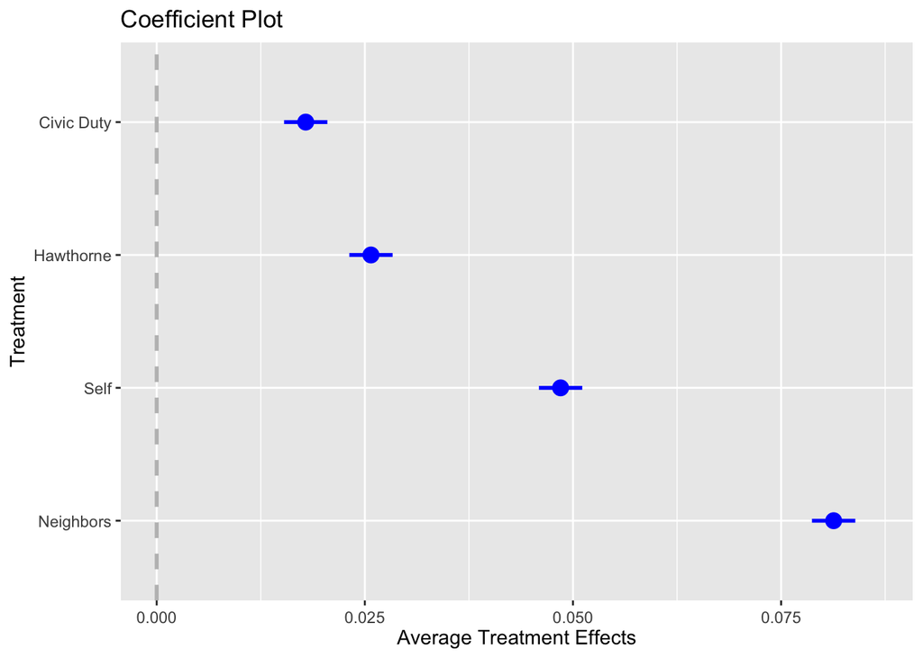

```r
# GG.Fit係数の可視化。切片なし。縦軸の順番を逆転
coefplot(GG.Fit1, intercept = FALSE, decreasing = TRUE,
         xlab = "Average Treatment Effects", # X軸の名前
         ylab = "Treatment", # Y軸の名前
         # このように縦軸名をカスタマイズすることも可能です。
         newNames = c("TreatCivic Duty" = "Civic Duty",
                      "TreatHawthorne"  = "Hawthorne",
                      "TreatNeighbors"  = "Neighbors",
                      "TreatSelf"       = "Self"),
         pointSize = 4) # ポイントの大きさ
```

これらの結果をどう評価すれば良いでしょうか。「隣人も投票しているよ」という葉書をもらった被験者は、何ももらっていない被験者よりも投票率が8.13%ポイント高いですね。統制群の投票率が29.7%で標準偏差が0.457なので、この葉書の効果は約0.178標準誤差分の効果があると言えるでしょう。効果量の指標である、Cohenの$d$だと、$d = 0.1726$であり、小さい効果量と考えられるかも知れませんが、葉書だけで投票率が8%ポイント上がることは政策的に十分に大きい効果だと判断できるでしょう。

## 重回帰分析

重回帰分析を使った分析もやってみましょう。ここでは性別（`Female`）、世帯内人数（`hh_size`）、誕生年（`yob`）、2000・2002・2004年選挙投票有無（`V2000`、`V2002`、`V2004`）を統制し、改めてATEを推定してみます。

$$\begin{array}
\hat{y} = & \beta_0 + \beta_1 \textrm{CivicDuty} + \beta_2 \textrm{Hawthorne} + \beta_3 \textrm{Neighbors} + \beta_4 \textrm{Self} + \\
& \beta_5 \textrm{Female} + \beta_6 \textrm{HouseholdSize} + \beta_7 \textrm{YearOfBrith} + \\
& \beta_8 \textrm{Voted2000} + \beta_9 \textrm{Voted2004} + \beta_{10} \textrm{Voted2004}.
\end{array}$$

やり方は先ほどとほぼ変わりません。`lm()`内のモデルを`結果 ~ 処置`から`結果 ~ 処置 + 共変量1 + 共変量2 + ...`へ変更するだけです。

```r
GG.Fit2 <- lm(Voted ~ Treat + Female + hh_size + yob +
                V2000 + V2002 + V2004, data = GG.df)

summary(GG.Fit2)
```

```
##
## Call:
## lm(formula = Voted ~ Treat + Female + hh_size + yob + V2000 +
##     V2002 + V2004, data = GG.df)
##
## Residuals:
##     Min      1Q  Median      3Q     Max
## -0.7679 -0.3344 -0.1953  0.5300  0.9359
##
## Coefficients:
##                   Estimate Std. Error t value Pr(>|t|)
## (Intercept)      5.845e+00  1.099e-01  53.202  < 2e-16
## TreatCivic Duty  1.839e-02  2.504e-03   7.343 2.10e-13
## TreatHawthorne   2.506e-02  2.504e-03  10.005  < 2e-16
## TreatSelf        4.797e-02  2.504e-03  19.157  < 2e-16
## TreatNeighbors   8.064e-02  2.504e-03  32.199  < 2e-16
## Female          -5.783e-03  1.525e-03  -3.791  0.00015
## hh_size          5.075e-03  1.018e-03   4.986 6.17e-07
## yob             -2.913e-03  5.642e-05 -51.633  < 2e-16
## V2000            9.401e-02  1.783e-03  52.722  < 2e-16
## V2002            1.414e-01  1.590e-03  88.876  < 2e-16
## V2004            1.578e-01  1.564e-03 100.838  < 2e-16
##
## Residual standard error: 0.4469 on 344073 degrees of freedom
## Multiple R-squared:  0.07592,    Adjusted R-squared:  0.0759
## F-statistic:  2827 on 10 and 344073 DF,  p-value: < 2.2e-16
```

続いて、点推定値とその不確実性を可視化します。

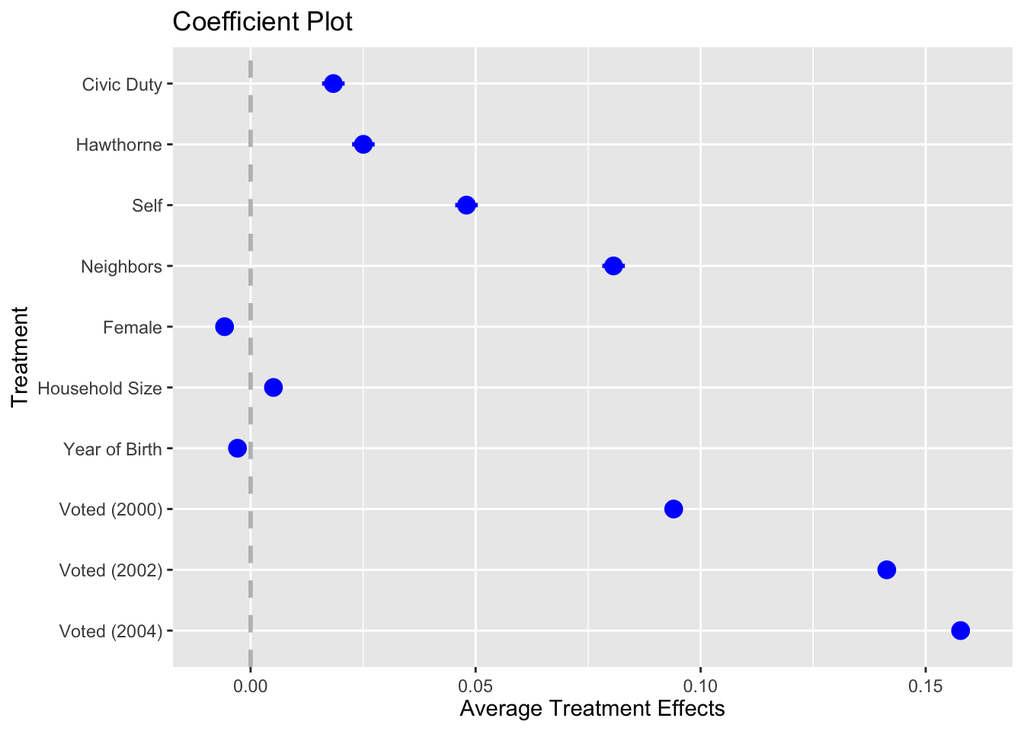

```r
# GG.Fit係数の可視化。切片なし。縦軸の順番を逆転
coefplot(GG.Fit2, intercept = FALSE, decreasing = TRUE,
         xlab = "Average Treatment Effects", # X軸の名前
         ylab = "Treatment", # Y軸の名前
         # このように縦軸名をカスタマイズすることも可能です。
         newNames = c("TreatCivic Duty" = "Civic Duty",
                      "TreatHawthorne"  = "Hawthorne",
                      "TreatNeighbors"  = "Neighbors",
                      "TreatSelf"       = "Self",
                      "hh_size"         = "Household Size",
                      "yob"             = "Year of Birth",
                      "V2000"           = "Voted (2000)",
                      "V2002"           = "Voted (2002)",
                      "V2004"           = "Voted (2004)"),
         pointSize = 4) # ポイントの大きさ
```

2つの回帰モデルから得られたパラメーターの推定値を比較してみましょう。R Markdownを使用している場合、`stargazer::stargzer()`関数が便利です。使い方は`stargazer(回帰モデル1, 回帰モデル2, ..., type = "html")`です。ただし、Markdownを使用している場合、Chunkオプションに`results = "asis"`を付けてください。また、`type = "html"`を省略した場合、$\LaTeX$形式の表が出力されます。Rコンソール上で結果を比較したいだけなら、`type = "text"`と指定します。

以下のコードには様々なオプションを付けてますが、各自1つずつ外しながら各オプションの意味を確かめてみてください。

```r
stargazer::stargazer(GG.Fit1, GG.Fit2,
                     # 小数点3桁まで出力、「*」を除去、数字を綺麗に揃える
                     digits = 3, star.cutoffs = NA, align = TRUE,
                     # サンプルサイズ、修正済みR2、F値を出力
                     # ただし、F値の自由度は省略する
                     keep.stat = c('n', 'adj.rsq', 'f'), df = FALSE,
                     # 表のタイトル指定
                     title = 'Results of Linear Regressions',
                     # 応答変数名を指定
                     dep.var.labels = 'Did R voted?',
                     # Dependent variableをOutcome variableに変更
                     dep.var.caption = 'Outcome variable',
                     # Notesを削除
                     omit.table.layout = "n",
                     # HTML形式で出力
                     type = "html")
```

**Results of Linear Regressions**

|  | Outcome variable |  |
| --- | --- | --- |
|  | Did R voted? |  |
|  | (1) | (2) |
| TreatCivic Duty | 0.018 | 0.018 |
|  | (0.003) | (0.003) |
| TreatHawthorne | 0.026 | 0.025 |
|  | (0.003) | (0.003) |
| TreatSelf | 0.049 | 0.048 |
|  | (0.003) | (0.003) |
| TreatNeighbors | 0.081 | 0.081 |
|  | (0.003) | (0.003) |
| Female |  | -0.006 |
|  |  | (0.002) |
| hh_size |  | 0.005 |
|  |  | (0.001) |
| yob |  | -0.003 |
|  |  | (0.0001) |
| V2000 |  | 0.094 |
|  |  | (0.002) |
| V2002 |  | 0.141 |
|  |  | (0.002) |
| V2004 |  | 0.158 |
|  |  | (0.002) |
| Constant | 0.297 | 5.845 |
|  | (0.001) | (0.110) |
| Observations | 344,084 | 344,084 |
| Adjusted R<sup>2</sup> | 0.003 | 0.076 |
| F Statistic | 292.976 | 2,826.942 |

処置がランダム化されているため、結果に大きな変化はありません。

## 分散分析を用いた処置効果の推定

回帰分析の場合、**“統制群に比べて”**各処置がどれほどの効果を持つかを推定する手法です。多くの場合、これで問題ありませんが、場合によっては処置群間の差を見るケースもあります。この場合、処置変数のベースラインを変えながら回帰分析を繰り返す方法もありますが、方法論上にも問題がありますし[^9]、なにより面倒くさいです。

むろん、処置群間の比較は多くの論文では見られません。ほとんどは統制群との差がメインとなっております。この場合、普通の回帰分析の方が結果の可視化もしやすく、紙幅の観点からもいいでしょう。それでも処置群間における平均処置効果の差の統計的有意性検定を行うなら、以下の方法があります。

統制群を含む複数のグループ間の比較は、やはり分散分析です。また、各グループ間に統計的に有意な差があるか否かを見るなら、多重比較 (multiple comparison)が必要です。

まず、分散分析から

```r
GG.ANOVA <- aov(Voted ~ Treat, data = GG.df)

summary(GG.ANOVA)
```

```
##                 Df Sum Sq Mean Sq F value Pr(>F)
## Treat            4    252   63.10     293 <2e-16
## Residuals   344079  74107    0.22
```

本当に見たいのは各ペアごとの平均値の差ですね。多重比較にはいくつかの方法がありますが、よく使われる方法としてTukey HSDがあります。ちなみにTukeyは人の名前で、HSDは*Honest Significant Differences*の略です。やり方は簡単です。

```r
TukeyHSD(GG.ANOVA)
```

```
##   Tukey multiple comparisons of means
##     95% family-wise confidence level
##
## Fit: aov(formula = Voted ~ Treat, data = GG.df)
##
## $Treat
##                             diff         lwr        upr    p adj
## Civic Duty-Control   0.017899344  0.01080625 0.02499243 0.000000
## Hawthorne-Control    0.025736312  0.01864214 0.03283048 0.000000
## Self-Control         0.048513191  0.04142010 0.05560628 0.000000
## Neighbors-Control    0.081309913  0.07421551 0.08840432 0.000000
## Hawthorne-Civic Duty 0.007836968 -0.00132162 0.01699556 0.134111
## Self-Civic Duty      0.030613847  0.02145610 0.03977160 0.000000
## Neighbors-Civic Duty 0.063410569  0.05425180 0.07256934 0.000000
## Self-Hawthorne       0.022776879  0.01361829 0.03193547 0.000000
## Neighbors-Hawthorne  0.055573601  0.04641399 0.06473321 0.000000
## Neighbors-Self       0.032796722  0.02363795 0.04195549 0.000000
```

これは各ペアごとに*t*検定を実施し、分析の数に合わせて*p*値にペナルティー (つまり、普通の*t*検定よりも大きい*p*値が出ます。)を与える方法です。

まず、`diff`列はペアの平均値の差です。1行目は`Civic Duty`処置群から統制群を引いたものであり、約`0.018`です。そして`lwr`と`upr`列はそれぞれ、差の95%信頼区間です。最後に`p adj`列は調整済み*p*値になります。唯一、統計的有意な差が見られないペアは`Hawthorne`と`Civic Duty`間であり、その差は約`0.008`、投票率で見ると0.8%ですね。

# 宋・矢内資料との対応関係

[宋財泫・矢内勇生.『私たちのR: ベストプラクティスの探究』](https://www.jaysong.net/RBook/)

- https://www.jaysong.net/RBook/

以下の内容は今後の講義においも非常に重要です。できれば、第6章から第17章まで読んでおくことをおすすめします。

- データの読み込み: [第7章](https://www.jaysong.net/RBook/io.html)
- tibble型データ構造: [第9.4章](https://www.jaysong.net/RBook/datastructure.html#structure-dataframe)
- dplyrパッケージの使い方: [第12章](https://www.jaysong.net/RBook/datahandling1.html)、[第13章](https://www.jaysong.net/RBook/datahandling2.html)
- factor型変数: [第8.6章](https://www.jaysong.net/RBook/datatype.html#type-factor)、[第14章](https://www.jaysong.net/RBook/factor.html)
- 可視化: [第16章](https://www.jaysong.net/RBook/visualization1.html)、[第17章](https://www.jaysong.net/RBook/visualization2.html)
[^1]: R内蔵関数である`ifelse()`を使っても問題ありません。
[^2]: `factor(x = treatment, levels = c("A", "B", "C"))`の場合、`x`と`levels`を仮引数（parameter）、`treatment`と`c("A", "B", "C")`を実引数（argument）と呼びます。第一仮引数（この場合は`x`）は省略する場合が多いです。
[^3]: 負の値も出ますが、最終的には絶対値を使います。二値変数 (binary variable)の場合、分母を$\sqrt{\frac{1}{2} \cdot \bar{X}_{\text{Treat}}(1-\bar{X}_{\text{Treat}}) + \bar{X}_{\text{Control}}(1-\bar{X}_{\text{Control}})}$に置き換えます。
[^4]: [Caliendo, Marco and Sabine Kopeinig, “Some Practical Guidance for the Implementation of Propensity Score Matching,” *Journal of Economic Survey*, 22(1), pp.31-72.](https://onlinelibrary.wiley.com/doi/full/10.1111/j.1467-6419.2007.00527.x)
[^5]: [Sharon-Lise T. Normand, Mary Beth Landrum, Edward Guadagnoli, John Z. Ayanian, Thomas J. Ryan, Paul D. Cleary, Barbara J. McNeil, 2001, “Validating recommendations for coronary angiography following acute myocardial infarction in the elderly: A matched analysis using propensity scores”, *Journal of Clinical Epidemiology,* 54(4), pp.387-398.](https://www.sciencedirect.com/science/article/pii/S0895435600003218?via%3Dihub)
[^6]: [Austin, Peter C. and Muhammad M. Mamdani, 2005, “A comparison of propensity score methods: a case‐study estimating the effectiveness of post‐AMI statin use,” *Statistics in Medicine,* 25(12), pp.2084-2106.](https://onlinelibrary.wiley.com/doi/abs/10.1002/sim.2328)
[^7]: [Ho, Daniel, Kosuke Imai, Gary King, Elizabeth A. Stuart, 2011, “MatchIt: Nonparametric Preprocessing for Parametric Causal Inference,” *Journal of Statistical Software,* 42(8).](https://www.jstatsoft.org/article/view/v042i08)
[^8]: `dplyr::select()`の使い方は[宋・矢内の参考資料](https://www.jaysong.net/RBook/datahandling1.html#handling1-select)を参照してください。
[^9]: *p*値の性質上、分析を繰り返すことによって統計的有意な差が見られる確率が高くなります。その意味で、ペアごとの*t*検定も望ましくありません。詳細は[Reinhart, Alex. 2015. *Statistics Done Wrong: The Woefully Complete Guide.* No Starch Press](http://amzn.asia/d/5nQXDkz)を参照して下さい（[『ダメな統計学』](http://amzn.asia/d/domd1Gl)という名で和訳もあります。）。